```python
import math
from datetime import datetime, timedelta
import pandas as pd
import numpy as np
import matplotlib.pyplot as plt
import seaborn
from matplotlib_venn import venn2
from tqdm import tqdm
from sklearn.preprocessing import OrdinalEncoder
from IPython.display import display
plt.style.use('seaborn-whitegrid')
%matplotlib inline

import japanize_matplotlib
pd.options.display.max_columns=50
```

# Load Data

```python
def load_data(input_dir:str ='../'):
    train_df = pd.read_csv('../input/train.csv.zip')
    test_df = pd.read_csv('../input/test.csv.zip')
    feature_df = pd.read_csv('../input/features.csv.zip')
    feature_df = feature_df.drop(['IsHoliday'], axis=1)
    store_df = pd.read_csv('../input/stores.csv')
    train_df = train_df.merge(feature_df, on=['Store', 'Date'], how='left')
    test_df = test_df.merge(feature_df, on=['Store', 'Date'], how='left')
    train_df = train_df.merge(store_df, on=['Store'], how='left')
    test_df = test_df.merge(store_df, on=['Store'], how='left')
    return train_df, test_df
```

```python
train_df, test_df = load_data()
```

```python
train_df.head()
```

|  | Store | Dept | Date | Weekly_Sales | IsHoliday | Temperature | Fuel_Price | MarkDown1 | MarkDown2 | MarkDown3 | MarkDown4 | MarkDown5 | CPI | Unemployment | Type | Size |
| --- | --- | --- | --- | --- | --- | --- | --- | --- | --- | --- | --- | --- | --- | --- | --- | --- |
| 0 | 1 | 1 | 2010-02-05 | 24924.50 | False | 42.31 | 2.572 | NaN | NaN | NaN | NaN | NaN | 211.096358 | 8.106 | A | 151315 |
| 1 | 1 | 1 | 2010-02-12 | 46039.49 | True | 38.51 | 2.548 | NaN | NaN | NaN | NaN | NaN | 211.242170 | 8.106 | A | 151315 |
| 2 | 1 | 1 | 2010-02-19 | 41595.55 | False | 39.93 | 2.514 | NaN | NaN | NaN | NaN | NaN | 211.289143 | 8.106 | A | 151315 |
| 3 | 1 | 1 | 2010-02-26 | 19403.54 | False | 46.63 | 2.561 | NaN | NaN | NaN | NaN | NaN | 211.319643 | 8.106 | A | 151315 |
| 4 | 1 | 1 | 2010-03-05 | 21827.90 | False | 46.50 | 2.625 | NaN | NaN | NaN | NaN | NaN | 211.350143 | 8.106 | A | 151315 |

```python
test_df.head()
```

|  | Store | Dept | Date | IsHoliday | Temperature | Fuel_Price | MarkDown1 | MarkDown2 | MarkDown3 | MarkDown4 | MarkDown5 | CPI | Unemployment | Type | Size |
| --- | --- | --- | --- | --- | --- | --- | --- | --- | --- | --- | --- | --- | --- | --- | --- |
| 0 | 1 | 1 | 2012-11-02 | False | 55.32 | 3.386 | 6766.44 | 5147.70 | 50.82 | 3639.90 | 2737.42 | 223.462779 | 6.573 | A | 151315 |
| 1 | 1 | 1 | 2012-11-09 | False | 61.24 | 3.314 | 11421.32 | 3370.89 | 40.28 | 4646.79 | 6154.16 | 223.481307 | 6.573 | A | 151315 |
| 2 | 1 | 1 | 2012-11-16 | False | 52.92 | 3.252 | 9696.28 | 292.10 | 103.78 | 1133.15 | 6612.69 | 223.512911 | 6.573 | A | 151315 |
| 3 | 1 | 1 | 2012-11-23 | True | 56.23 | 3.211 | 883.59 | 4.17 | 74910.32 | 209.91 | 303.32 | 223.561947 | 6.573 | A | 151315 |
| 4 | 1 | 1 | 2012-11-30 | False | 52.34 | 3.207 | 2460.03 | NaN | 3838.35 | 150.57 | 6966.34 | 223.610984 | 6.573 | A | 151315 |

# 基本情報

```python
print('店舗数', train_df['Store'].nunique())
print('部門数', train_df['Dept'].nunique())
```

```
店舗数 45
部門数 81
```

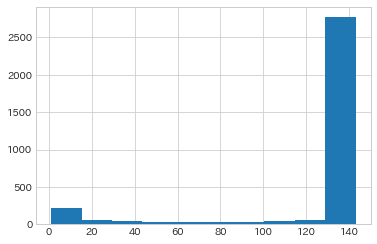

```python
train_df.groupby(['Store', 'Dept'])['Date'].count().hist(bins=10)
```

- 過去の実績数が少ない部門もある(売り上げ0ってこと？？)

```python
count_df = train_df.groupby(['Store', 'Dept'])['Date'].count()
count_df[count_df < 20]
```

```
Store  Dept
1      77       3
       78       4
2      39       4
       51      12
       77       2
               ..
44     99       2
45     47      12
       77       8
       78       8
       96       2
Name: Date, Length: 244, dtype: int64
```

```python
# 具体例
display(train_df.query('Store==1 & Dept==77'))
display(train_df.query('Store==2 & Dept==39'))
display(train_df.query('Store==45 & Dept==96'))
```

|  | Store | Dept | Date | Weekly_Sales | IsHoliday | Temperature | Fuel_Price | MarkDown1 | MarkDown2 | MarkDown3 | MarkDown4 | MarkDown5 | CPI | Unemployment | Type | Size |
| --- | --- | --- | --- | --- | --- | --- | --- | --- | --- | --- | --- | --- | --- | --- | --- | --- |
| 7933 | 1 | 77 | 2011-11-25 | 1431.0 | True | 60.14 | 3.236 | 410.31 | 98.00 | 55805.51 | 8.00 | 554.92 | 218.467621 | 7.866 | A | 151315 |
| 7934 | 1 | 77 | 2011-12-02 | 204.0 | False | 48.91 | 3.172 | 5629.51 | 68.00 | 1398.11 | 2084.64 | 20475.32 | 218.714733 | 7.866 | A | 151315 |
| 7935 | 1 | 77 | 2012-01-20 | 396.0 | False | 54.11 | 3.268 | 4139.87 | 2807.19 | 33.88 | 500.62 | 3400.21 | 219.985689 | 7.348 | A | 151315 |

|  | Store | Dept | Date | Weekly_Sales | IsHoliday | Temperature | Fuel_Price | MarkDown1 | MarkDown2 | MarkDown3 | MarkDown4 | MarkDown5 | CPI | Unemployment | Type | Size |
| --- | --- | --- | --- | --- | --- | --- | --- | --- | --- | --- | --- | --- | --- | --- | --- | --- |
| 15505 | 2 | 39 | 2010-02-19 | 0.78 | False | 39.69 | 2.514 | NaN | NaN | NaN | NaN | NaN | 210.945160 | 8.324 | A | 202307 |
| 15506 | 2 | 39 | 2010-02-26 | 7.02 | False | 46.10 | 2.561 | NaN | NaN | NaN | NaN | NaN | 210.975957 | 8.324 | A | 202307 |
| 15507 | 2 | 39 | 2010-03-05 | 0.78 | False | 47.17 | 2.625 | NaN | NaN | NaN | NaN | NaN | 211.006754 | 8.324 | A | 202307 |
| 15508 | 2 | 39 | 2010-03-19 | 0.78 | False | 54.52 | 2.720 | NaN | NaN | NaN | NaN | NaN | 210.873332 | 8.324 | A | 202307 |

|  | Store | Dept | Date | Weekly_Sales | IsHoliday | Temperature | Fuel_Price | MarkDown1 | MarkDown2 | MarkDown3 | MarkDown4 | MarkDown5 | CPI | Unemployment | Type | Size |
| --- | --- | --- | --- | --- | --- | --- | --- | --- | --- | --- | --- | --- | --- | --- | --- | --- |
| 421290 | 45 | 96 | 2012-03-16 | 3.00 | False | 50.56 | 3.862 | 5811.44 | 375.7 | 3.69 | 3444.05 | 2706.47 | 190.461896 | 8.424 | B | 118221 |
| 421291 | 45 | 96 | 2012-09-14 | 2.94 | False | 67.87 | 3.948 | 11407.95 | NaN | 4.30 | 3421.72 | 5268.92 | 191.699850 | 8.684 | B | 118221 |

- 特に連続性もないので、売り上げが少ない部門なのかも

## 訓練とテストの重複割合

```python
def plot_venn2(df1:pd.DataFrame, df2:pd.DataFrame, col:str)-> None:
    n_intersect = len(set(df1[col]) & set(df2[col]))
    venn2((df1[col].nunique() - n_intersect, df2[col].nunique() - n_intersect, n_intersect))
```

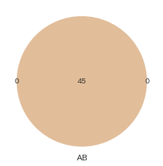

```python
plot_venn2(train_df, test_df, 'Store')
```

```python
train_df['id'] = train_df['Store'].astype('str') + '_' + train_df['Dept'].astype('str')
test_df['id'] = test_df['Store'].astype('str') + '_' + test_df['Dept'].astype('str')
```

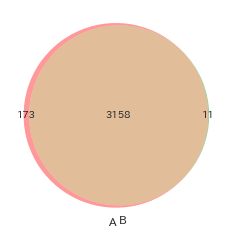

```python
# 部門まで含めた重複
plot_venn2(train_df, test_df, 'id')
```

- テスト期間にしか存在しない部門は売り上げが低そうなので0埋めする？

```python
print('train期間', train_df['Date'].min(), train_df['Date'].max())
```

```
train期間 2010-02-05 2012-10-26
```

```python
print('test期間', test_df['Date'].min(), test_df['Date'].max())
```

```
test期間 2012-11-02 2013-07-26
```

- リアルタイムデータは使えない
- 正直8ヶ月分も未来をまともに予測できる気がしない
  - 自己回帰モデルとかの方がいいかも
  - リアルタイムデータが使えないので統計値でもまあまあ当たりそう

## 時系列

```python
train_df['Date'] = pd.to_datetime(train_df["Date"], infer_datetime_format=True)
test_df['Date'] = pd.to_datetime(test_df["Date"], infer_datetime_format=True)
```

```python
all_df = pd.concat([train_df, test_df], axis=0, sort=False)
```

```python
all_df['year'] = all_df['Date'].dt.year
all_df["weekofyear"] = all_df["Date"].dt.weekofyear
```

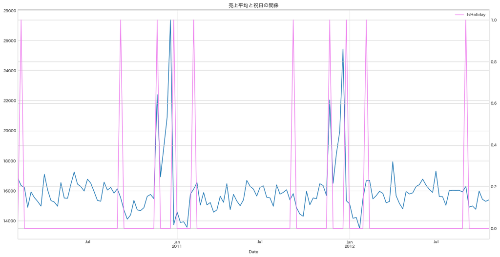

```python
ax = train_df.groupby(['Date'])["Weekly_Sales"].mean().plot(figsize=(20, 10))
holiday_df = train_df[['Date', 'IsHoliday']].drop_duplicates()
ax2 = ax.twinx()
holiday_df.set_index('Date')[['IsHoliday']].astype(int).plot(ax=ax2, color='violet')
ax.set_title('売上平均と祝日の関係');
```

- 11月の祝日(Thanksgiving)は明らかに相関がある。
- 12月の祝日(Chrithmath)はその1week前とかにpeekがきてる。
  - 祝日の前日みたいなのを捉えてもらうためにweek_of_yearとかは大事な気がする
- 週の頭の日にちがDateになっているので、何周目なのかとかでNormalizeした方が良さそう

```python
# とりあえず11と12の祝日だけ切り出す関数は作っておく
def extract_holiday(df:pd.DataFrame, month:int):
    month2holiday = {
        11: "Thanksgiving",
        12: "Christmas"
    }
    holiday_name = month2holiday[month]
    df[holiday_name] = 0
    df.loc[df.query('IsHoliday==1 & month==@month').index, holiday_name] = 1
    return df
```

- Sizeで売り上げをNormalize

```python
train_df['norm_sales'] = train_df['Weekly_Sales'] / train_df['Size']
```

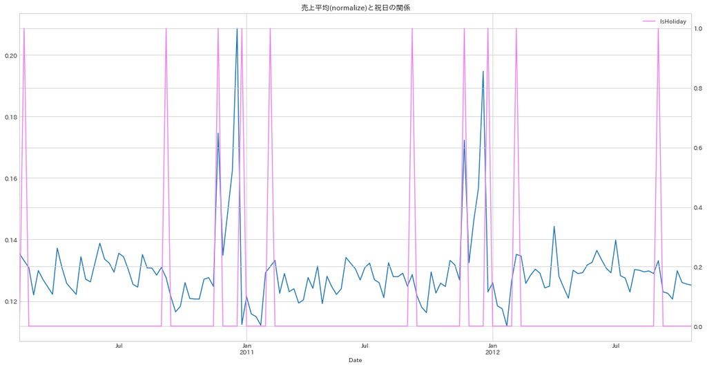

```python
ax = train_df.groupby(['Date'])["norm_sales"].mean().plot(figsize=(20, 10))
holiday_df = train_df[['Date', 'IsHoliday']].drop_duplicates()
ax2 = ax.twinx()
holiday_df.set_index('Date')[['IsHoliday']].astype(int).plot(ax=ax2, color='violet')
ax.set_title('売上平均(normalize)と祝日の関係');
```

- あまり変わらない

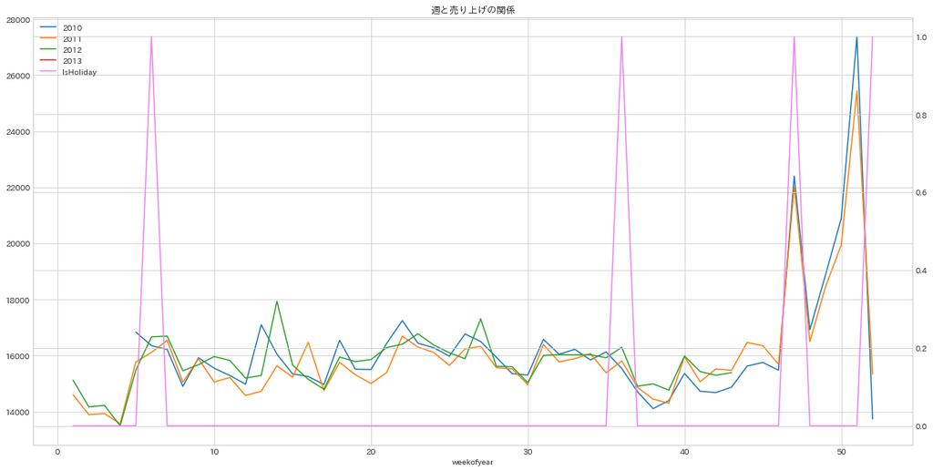

```python
holiday_df = all_df[['weekofyear', 'IsHoliday']].drop_duplicates().sort_values('weekofyear')
for year, year_df in all_df.groupby('year'):
    ax = year_df.groupby(['weekofyear'])["Weekly_Sales"].mean().plot(figsize=(20, 10), label=year)
ax.legend()
ax2 = ax.twinx()
holiday_df.set_index('weekofyear')['IsHoliday'].astype(int).plot(ax=ax2, color='violet', label='IsHoliday')
h1, l1 = ax.get_legend_handles_labels()
h2, l2 = ax2.get_legend_handles_labels()
ax.legend(h1+h2, l1+l2, loc=2)
ax.set_title('週と売り上げの関係');
```

- 定常性がある
- 11月の祝日は2年連続で同じ傾向
- 12月の祝日は少し違う傾向
  - 年末は少し上がり、その前の週が少し上がっているので、週毎の集計値なのが悪さしてそう
  - 次の年は、更にずれる可能性がある

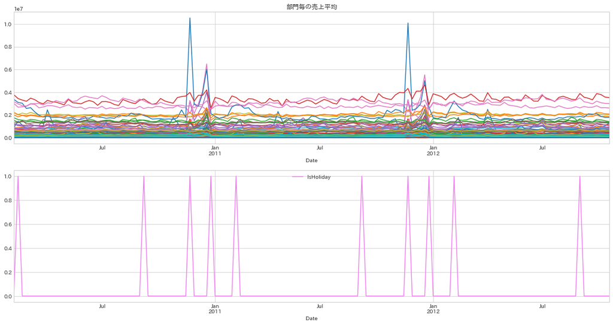

```python
ax = plt.subplot(211)
train_df.groupby(['Date', 'Dept'])["Weekly_Sales"].sum().unstack(1).fillna(0).plot(ax=ax, figsize=(20, 10))
ax.get_legend().remove()
holiday_df = train_df[['Date', 'IsHoliday']].drop_duplicates()
ax2 = plt.subplot(212)
holiday_df.set_index('Date')[['IsHoliday']].astype(int).plot(ax=ax2, color='violet')
ax.set_title('部門毎の売上平均');
```

- 割と部門によってトレンドが違いそう。
  - 一部の部門は11月、12月以外の祝日にも反応している
  - Dept単位の集計値も特徴量に加えた方が良さそう

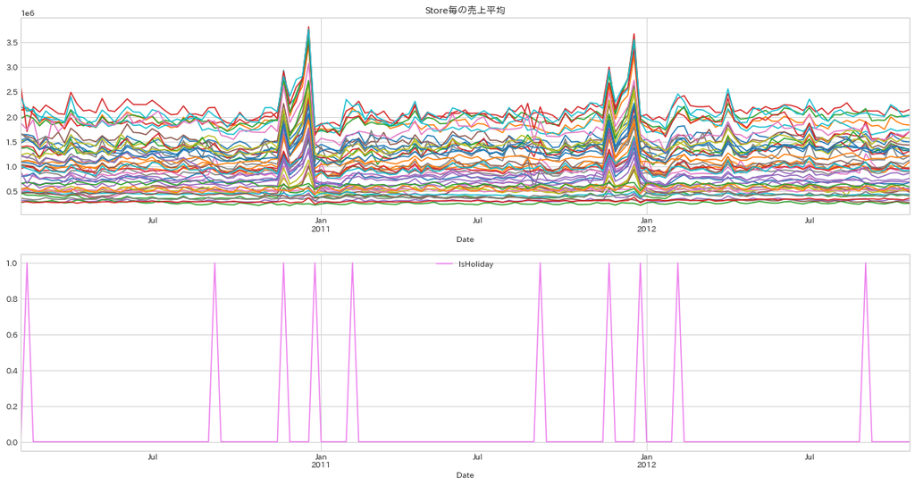

```python
ax = plt.subplot(211)
train_df.groupby(['Date', 'Store'])["Weekly_Sales"].sum().unstack(1).fillna(0).plot(ax=ax, figsize=(20, 10))
ax.get_legend().remove()
holiday_df = train_df[['Date', 'IsHoliday']].drop_duplicates()
ax2 = plt.subplot(212)
holiday_df.set_index('Date')[['IsHoliday']].astype(int).plot(ax=ax2, color='violet')
ax.set_title('Store毎の売上平均');
```

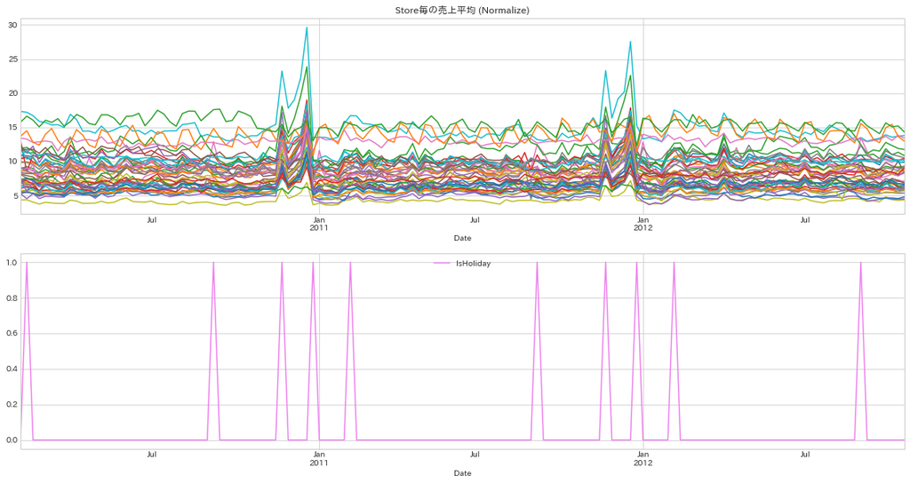

```python
ax = plt.subplot(211)
train_df.groupby(['Date', 'Store'])["norm_sales"].sum().unstack(1).fillna(0).plot(ax=ax, figsize=(20, 10))
ax.get_legend().remove()
holiday_df = train_df[['Date', 'IsHoliday']].drop_duplicates()
ax2 = plt.subplot(212)
holiday_df.set_index('Date')[['IsHoliday']].astype(int).plot(ax=ax2, color='violet')
ax.set_title('Store毎の売上平均 (Normalize)');
```

- SizeでNormalizeすると売り上げの違いがよく見えるので、norm済みの売り上げでも特徴量作成してみてもいいかも

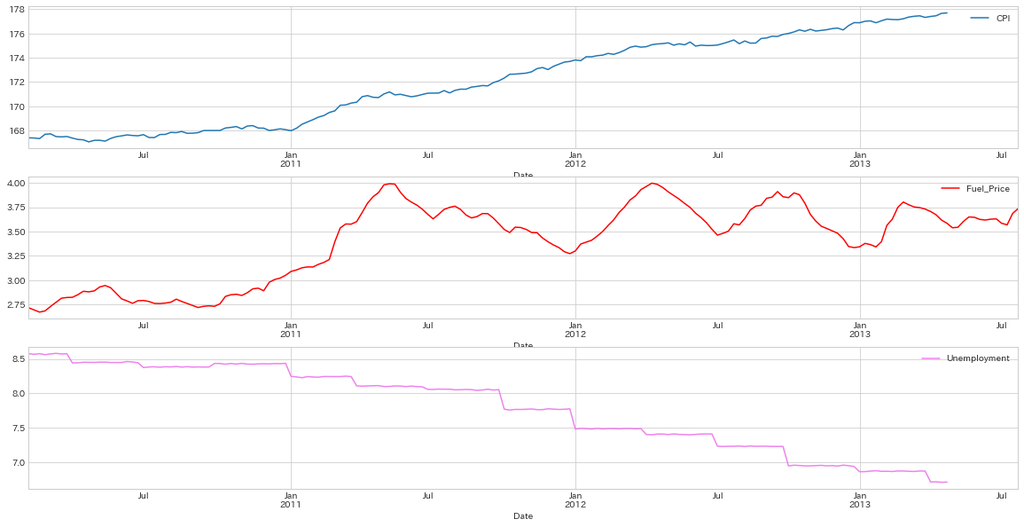

```python
ax = plt.subplot(311)
all_df.groupby(['Date'])[['CPI']].mean().plot(ax=ax, figsize=(20, 10))
# holiday_df = all_df[['Date', 'IsHoliday']].drop_duplicates()
ax = plt.subplot(312)
all_df.groupby(['Date'])[['Fuel_Price']].mean().plot(ax=ax, color='r', figsize=(20, 10))
ax = plt.subplot(313)
all_df.groupby(['Date'])[['Unemployment']].mean().plot(ax=ax, color='violet', figsize=(20, 10));
# holiday_df.set_index('Date')[['IsHoliday']].astype(int).plot(ax=ax2, color='violet', figsize=(20, 10))
```

- 失業率が下がり、CPIも上がって景気は上がってきているので全体的にtest期間では上がり調子なはず

# ベースラインモデル

```python
import lightgbm as lgb
from sklearn.preprocessing import OrdinalEncoder
from sklearn.model_selection import GroupKFold
from tqdm import tqdm
```

- 方針
  - validationの作成が相当難しい
  - test期間が9ヶ月なため、本来は9ヶ月未来をvalid、それ以前の期間の9ヶ月より後ろの期間で特徴量作成を行うべきであるが、それだと与えられてる期間から使える情報が少なくなってしまう。
  - そこで、上の時系列性から見てそこまで年ごとに変化がない、monthごとにGroupKFoldをしてsubmitしてみることで有効性を確かめる
  - 比較として単純に統計値を用いたものを提出する
    - Private: 3217.38001, Public: 3162.79282

## 統計値

```python
train_df, test_df = load_data()
```

```python
def extract_date_feature(df:pd.DataFrame)-> pd.DataFrame:
    df['Date'] = pd.to_datetime(df["Date"], infer_datetime_format=True)
    df['month'] = df['Date'].dt.month
    df['day'] = df['Date'].dt.day
    # Normalize
    df['week'] = df['day'] // 7
    df.loc[df.query('week >= 4').index, 'week'] = 3
    df['weekofyear'] = df['Date'].dt.weekofyear
    return df
```

```python
train_df = extract_date_feature(train_df)
test_df = extract_date_feature(test_df)
```

```python
# 部門・月・週ごと平均
stat_df = train_df.groupby(['Store', "Dept", 'month', 'week'])['Weekly_Sales'].mean()
stat_df.name = f'mean_{stat_df.name}_dept_week'
test_df = test_df.merge(stat_df, on=['Store', "Dept", 'month', 'week'], how='left')

# 部門・月ごと平均
stat_df = train_df.groupby(['Store', "Dept", 'month'])['Weekly_Sales'].mean()
stat_df.name = f'mean_{stat_df.name}_dept_month'
test_df = test_df.merge(stat_df, on=['Store', "Dept", 'month'], how='left')

# 部門ごと平均
stat_df = train_df.groupby(['Store', "Dept"])['Weekly_Sales'].mean()
stat_df.name = f'mean_{stat_df.name}_dept'
test_df = test_df.merge(stat_df, on=['Store', "Dept"], how='left')

# 店舗ごと平均
stat_df = train_df.groupby(['Store'])['Weekly_Sales'].mean()
stat_df.name = f'mean_{stat_df.name}'
test_df = test_df.merge(stat_df, on=['Store'], how='left')
```

```python
# 細かい統計値から順にNULL埋めを行う
test_df['mean_Weekly_Sales_dept_week'].fillna(test_df['mean_Weekly_Sales_dept_month'], inplace=True)
test_df['mean_Weekly_Sales_dept_week'].fillna(test_df['mean_Weekly_Sales_dept'], inplace=True)
# test_df['mean_Weekly_Sales_dept_week'].fillna(test_df['mean_Weekly_Sales'], inplace=True)
test_df['mean_Weekly_Sales_dept_week'].fillna(0, inplace=True)
```

```python
test_df['id'] = test_df['Store'].astype('str') + '_' + test_df['Dept'].astype('str')+ '_' + test_df['Date'].astype('str')
```

```python
test_df['Weekly_Sales'] = test_df['mean_Weekly_Sales_dept_week']
test_df[['id', 'Weekly_Sales']].to_csv('../output/stats.csv', index=False)
```

```python
stat_df = train_df.groupby(['Store', "Dept", 'month', 'week'])['Weekly_Sales'].mean()
stat_df.name = f'mean_{stat_df.name}_dept_week'
train_df = train_df.merge(stat_df, on=['Store', "Dept", 'month', 'week'], how='left')
```

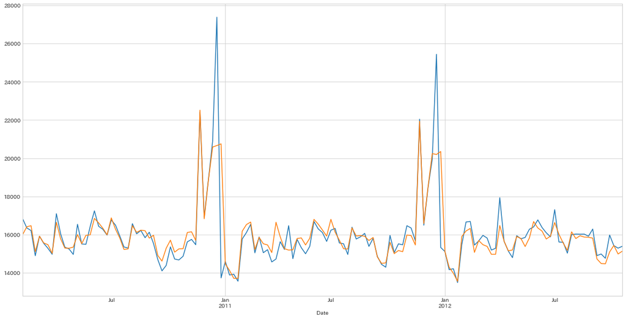

```python
ax = train_df.groupby(['Date'])["Weekly_Sales"].mean().plot(figsize=(20, 10))
train_df.groupby(['Date'])["mean_Weekly_Sales_dept_week"].mean().plot(ax=ax)
```

- 12月末に関して、weekのnormalizeが悪い方向に働いてしまっている
  - 12月に関してはNormalizeを外す

```python
train_df, test_df = load_data()
```

```python
def extract_date_feature(df:pd.DataFrame)-> pd.DataFrame:
    df['Date'] = pd.to_datetime(df["Date"], infer_datetime_format=True)
    df['month'] = df['Date'].dt.month
    df['day'] = df['Date'].dt.day
    # Normalize
    df['week'] = df['day'] // 7
    df.loc[df.query('week >= 4 & month!=12').index, 'week'] = 3
    df['weekofyear'] = df['Date'].dt.weekofyear
    return df
```

```python
train_df = extract_date_feature(train_df)
test_df = extract_date_feature(test_df)
```

```python
# 部門・月・週ごと平均
stat_df = train_df.groupby(['Store', "Dept", 'month', 'week'])['Weekly_Sales'].mean()
stat_df.name = f'mean_{stat_df.name}_dept_week'
test_df = test_df.merge(stat_df, on=['Store', "Dept", 'month', 'week'], how='left')

# 部門・月ごと平均
stat_df = train_df.groupby(['Store', "Dept", 'month'])['Weekly_Sales'].mean()
stat_df.name = f'mean_{stat_df.name}_dept_month'
test_df = test_df.merge(stat_df, on=['Store', "Dept", 'month'], how='left')

# 部門ごと平均
stat_df = train_df.groupby(['Store', "Dept"])['Weekly_Sales'].mean()
stat_df.name = f'mean_{stat_df.name}_dept'
test_df = test_df.merge(stat_df, on=['Store', "Dept"], how='left')

# 店舗ごと平均
stat_df = train_df.groupby(['Store'])['Weekly_Sales'].mean()
stat_df.name = f'mean_{stat_df.name}'
test_df = test_df.merge(stat_df, on=['Store'], how='left')
```

```python
# 細かい統計値から順にNULL埋めを行う
test_df['mean_Weekly_Sales_dept_week'].fillna(test_df['mean_Weekly_Sales_dept_month'], inplace=True)
test_df['mean_Weekly_Sales_dept_week'].fillna(test_df['mean_Weekly_Sales_dept'], inplace=True)
# test_df['mean_Weekly_Sales_dept_week'].fillna(test_df['mean_Weekly_Sales'], inplace=True)
test_df['mean_Weekly_Sales_dept_week'].fillna(0, inplace=True)
```

```python
test_df['id'] = test_df['Store'].astype('str') + '_' + test_df['Dept'].astype('str')+ '_' + test_df['Date'].astype('str')
```

```python
test_df['Weekly_Sales'] = test_df['mean_Weekly_Sales_dept_week']
test_df[['id', 'Weekly_Sales']].to_csv('../output/stats_v2.csv', index=False)
```

```python
stat_df = train_df.groupby(['Store', "Dept", 'month', 'week'])['Weekly_Sales'].mean()
stat_df.name = f'mean_{stat_df.name}_dept_week'
train_df = train_df.merge(stat_df, on=['Store', "Dept", 'month', 'week'], how='left')
```

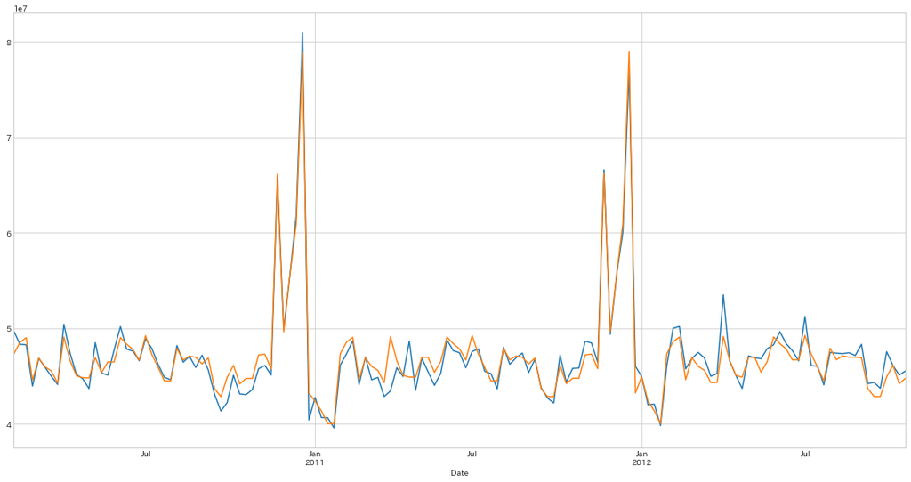

```python
ax = train_df.groupby(['Date'])["Weekly_Sales"].sum().plot(figsize=(20, 10))
train_df.groupby(['Date'])["mean_Weekly_Sales_dept_week"].sum().plot(ax=ax)
```